# **Stat 112 - Recitation 8**

> Ozancan Ozdemir - ozancan@metu.edu.tr

## **Introduction to Pandas**

This introduction sentence is created by [ChatGPT](https://chat.openai.com/chat)

Pandas is a software library written for the Python programming language for data manipulation and analysis. It is often used for working with data in tabular form, such as data stored in a spreadsheet or a database table.

Pandas provides a powerful set of tools for working with and analyzing data, including data frames, which are similar to tables in a relational database, and tools for working with time series data.

To install pandas on Anaconda, you should run the following command on your Anaconda terminal.

`conda install pandas`

However, we do not have such a problem with colaboratory. :)

Once Pandas is installed, you can import it into your Python script using the following code:

```python
import pandas as pd #import the package
```

The `pd` alias will be used to reference Pandas throughout your code.

In Pandas, the three main data structures for storing and working with data are the Series, the DataFrame and the Panel.

A Series is a one-dimensional array-like object that can hold any data type. It has a labeled index, which is used to access the elements of the Series.

A DataFrame is a 2-dimensional tabular data structure that can hold any data type. It is similar to a spreadsheet or a SQL table. A DataFrame has a labeled index and labeled columns, which allow you to access the data in the table using the labels rather than numeric indices.

A Panel is a 3-dimensional data container. However, we are mostly using Pandas with DataFrame. At least in this course.

You can think of a DataFrame as a collection of Series objects that share the same index. This makes it easy to perform operations on data in the table, such as selecting specific rows or columns, or applying calculations to entire columns of data.

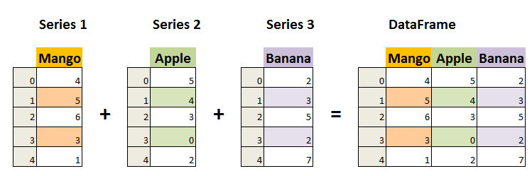

Source: [Data Science Made Simple](https://www.datasciencemadesimple.com/create-series-in-python-pandas/)

You can create a Series or DataFrame in Pandas by passing a list or array of data to the pandas.Series() or pandas.DataFrame() constructor, respectively. You can also import data from a file or other data source into a DataFrame using the pandas.read_*() functions, where the* is replaced with the file format (e.g. csv or excel).

```python
# create a Series
s = pd.Series([1,9,5,6])
print(s)
```

```
0    1
1    9
2    5
3    6
dtype: int64
```

```python
# create a DataFrame
df = pd.DataFrame([[1, 2, 3], [4, 5, 6], [7, 8, 9]])
print(df)
```

```
   0  1  2
0  1  2  3
1  4  5  6
2  7  8  9
```

Although the created objects above include only integers, there are several data types that can be used in a Pandas DataFrame, including:

- object: a string or mixed data type
- int64: a 64-bit integer
- float64: a 64-bit floating-point number
- bool: a boolean value (True or False)
- datetime64: a date and time, stored in a 64-bit format
- timedelta[ns]: a duration of time, stored in a 64-bit format

These are just some of the data types that can be used in Pandas. You can use the DataFrame.dtypes property to view the data type for each column in a DataFrame.

```python
df.dtypes
```

```
0    int64
1    int64
2    int64
dtype: object
```

### **Creating Data Frame from Scratch**

In pandas, there are two main ways to create a data frame from scratch, `list`, `dictionary`. The usage of list in creating data frame has already done above. Now, we will look at how to use dictionaries to create a data frame in pandas.

Note that dictionaries provides an advantage over assigning a column name to your data frame.

When you use list to create a data frame, you have to define the column names after that. However, you can both define column names and values at the same time in dictionary.

**Reminder**

A typical dictionary object in Python has the following structure.

`dict_name = {'key' : value}`

or

`dict_name = { 'key' : [value1,value2] }`

Key and value can be either integer or character.

```python
# Dictionary with integer keys
my_dict = {1: 'A', 2: 'B'}
print(my_dict)

# Dictionary with string keys
my_dict = {'name': 'ozan', 'age': 28}
print(my_dict)

# Dictionary with mixed keys
my_dict = {'name': 'ozan', 1: ['A', 'B']}
print(my_dict)
```

```
{1: 'A', 2: 'B'}
{'name': 'ozan', 'age': 28}
{'name': 'ozan', 1: ['A', 'B']}
```

Now, we will create the following table using dictonaries. In doing so, we use `pd.DataFrame()` constructor.

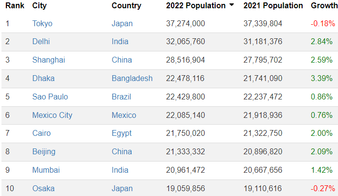

```python
table = pd.DataFrame({'City' : ['Tokyo','Delhi','Shangai','Dhaka','Sao Paulo','Mexico City','Cairo','Beijing','Mumbai','Osaka'],
                      'Country': ['Japan','India','China','Bangladesh','Brazil','Mexico','Egypt','China','India','Japan'],
                      '2022 Population':[37274000,32065760,28516904,22478116,22429800,22085140,21750020,21333332,20961472,19059856],
                      '2021 Population': [37339804,31181376,27795702,21741090,22237472,21918936,21322750,20896820,20667656,19110616],
                      'Growth': [-0.18,2.84,2.59,3.39,0.86,0.76,2,2.09,1.42,-0.27]})

print(table)
```

```
          City     Country  2022 Population  2021 Population  Growth
0        Tokyo       Japan         37274000         37339804   -0.18
1        Delhi       India         32065760         31181376    2.84
2      Shangai       China         28516904         27795702    2.59
3        Dhaka  Bangladesh         22478116         21741090    3.39
4    Sao Paulo      Brazil         22429800         22237472    0.86
5  Mexico City      Mexico         22085140         21918936    0.76
6        Cairo       Egypt         21750020         21322750    2.00
7      Beijing       China         21333332         20896820    2.09
8       Mumbai       India         20961472         20667656    1.42
9        Osaka       Japan         19059856         19110616   -0.27
```

#### **Exercise 1**

Please create the following DataFrame and name **ex1**.

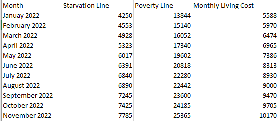

After creating the data frame, we will introduce some Pandas attributes on data frame.

```python
table.dtypes #list the data types of the series
```

```
City                object
Country             object
2022 Population      int64
2021 Population      int64
Growth             float64
dtype: object
```

```python
table.shape #shows the number of column and rows of your data frame
```

```
(10, 5)
```

**Displaying the general information about data frame:** You can print the information above together using `df.info()` attribute where `df` shows the name of the data frame.

```python
table.info()
```

```
<class 'pandas.core.frame.DataFrame'>
RangeIndex: 10 entries, 0 to 9
Data columns (total 5 columns):
 #   Column           Non-Null Count  Dtype
---  ------           --------------  -----
 0   City             10 non-null     object
 1   Country          10 non-null     object
 2   2022 Population  10 non-null     int64
 3   2021 Population  10 non-null     int64
 4   Growth           10 non-null     float64
dtypes: float64(1), int64(2), object(2)
memory usage: 528.0+ bytes
```

When you create a longer data frame, it is not necessary to view all observations. `df.head()` funciton will show first 5 observations in your data while `df.tail()` shows the last 5 observations.

```python
table.head() #shows first 5 observations
```

|  | City | Country | 2022 Population | 2021 Population | Growth |
| --- | --- | --- | --- | --- | --- |
| 0 | Tokyo | Japan | 37274000 | 37339804 | -0.18 |
| 1 | Delhi | India | 32065760 | 31181376 | 2.84 |
| 2 | Shangai | China | 28516904 | 27795702 | 2.59 |
| 3 | Dhaka | Bangladesh | 22478116 | 21741090 | 3.39 |
| 4 | Sao Paulo | Brazil | 22429800 | 22237472 | 0.86 |

```python
table.head(3) #shows first three observations
```

|  | City | Country | 2022 Population | 2021 Population | Growth |
| --- | --- | --- | --- | --- | --- |
| 0 | Tokyo | Japan | 37274000 | 37339804 | -0.18 |
| 1 | Delhi | India | 32065760 | 31181376 | 2.84 |
| 2 | Shangai | China | 28516904 | 27795702 | 2.59 |

**Adding a new column:** You can add new intel to your data frame easily. Let's add the continent of the countries. But first, create your continent object.

```python
import numpy as np

continent =  np.repeat(np.array(['Asia','S.America','Africa','Asia']),[4,2,1,3],axis = 0)
continent
```

```
array(['Asia', 'Asia', 'Asia', 'Asia', 'S.America', 'S.America', 'Africa',
       'Asia', 'Asia', 'Asia'], dtype='<U9')
```

```python
table['continent']  = continent
#df_name['new column name'] = new series
table.head()
```

|  | City | Country | 2022 Population | 2021 Population | Growth | continent |
| --- | --- | --- | --- | --- | --- | --- |
| 0 | Tokyo | Japan | 37274000 | 37339804 | -0.18 | Asia |
| 1 | Delhi | India | 32065760 | 31181376 | 2.84 | Asia |
| 2 | Shangai | China | 28516904 | 27795702 | 2.59 | Asia |
| 3 | Dhaka | Bangladesh | 22478116 | 21741090 | 3.39 | Asia |
| 4 | Sao Paulo | Brazil | 22429800 | 22237472 | 0.86 | S.America |

```python
table.columns # list the columns in the data
```

```
Index(['City', 'Country', '2022 Population', '2021 Population', 'Growth',
       'continent'],
      dtype='object')
```

**Subsetting a Data Frame:** Pandas provides several ways to assess a subset of the DataFrame. In other words, you can pull out specific rows, columns, slices or cells in the DataFrame object using different ways.

```python
table['City']
#df_name['Column name']
```

```
0          Tokyo
1          Delhi
2        Shangai
3          Dhaka
4      Sao Paulo
5    Mexico City
6          Cairo
7        Beijing
8         Mumbai
9          Osaka
Name: City, dtype: object
```

```python
table[['City','Country']]
#for multiple extraction, create a list object.
```

|  | City | Country |
| --- | --- | --- |
| 0 | Tokyo | Japan |
| 1 | Delhi | India |
| 2 | Shangai | China |
| 3 | Dhaka | Bangladesh |
| 4 | Sao Paulo | Brazil |
| 5 | Mexico City | Mexico |
| 6 | Cairo | Egypt |
| 7 | Beijing | China |
| 8 | Mumbai | India |
| 9 | Osaka | Japan |

You can acess your data using `loc[]` and `iloc[]` in Pandas.

loc stands for "location" and is used to select data by the labels of the rows and columns. For example, to select the first row of a DataFrame, you would use `df.loc[0]`.

iloc stands for "integer location" and is used to select data by the position of the rows and columns. So, to select the first row of a DataFrame using iloc, you would use `df.iloc[0]`.

One key difference between the two is that loc uses the labels of the rows and columns to identify which data to select, while iloc uses the integer positions of the rows and columns.

This means that if you have changed the row labels or column names, loc will still use the original labels, while iloc will use the current integer positions of the rows and columns.

**Indexing starts from 0 in Pandas, as in Numpy.**

```python
table.loc[0] #first row of the data
```

```
City                  Tokyo
Country               Japan
2022 Population    37274000
2021 Population    37339804
Growth                -0.18
continent              Asia
Name: 0, dtype: object
```

Since we do not have row label names in this data, we use number in loc.

```python
table.iloc[[0,3,8]] #1st, 4th, 9th rows of the data
```

|  | City | Country | 2022 Population | 2021 Population | Growth | continent |
| --- | --- | --- | --- | --- | --- | --- |
| 0 | Tokyo | Japan | 37274000 | 37339804 | -0.18 | Asia |
| 3 | Dhaka | Bangladesh | 22478116 | 21741090 | 3.39 | Asia |
| 8 | Mumbai | India | 20961472 | 20667656 | 1.42 | Asia |

```python
table['City'].iloc[2] #the name of the third city
```

```
'Shangai'
```

You can use boolean indexing for slicing a DataFrame in Pandas. Remember that boolean indexing is useful when you access your data based on a **condition.**

For example, we would like to list the information of the cities whose current population exceeds 24000000.

```python
table[table['2022 Population']>24000000]
```

|  | City | Country | 2022 Population | 2021 Population | Growth | continent |
| --- | --- | --- | --- | --- | --- | --- |
| 0 | Tokyo | Japan | 37274000 | 37339804 | -0.18 | Asia |
| 1 | Delhi | India | 32065760 | 31181376 | 2.84 | Asia |
| 2 | Shangai | China | 28516904 | 27795702 | 2.59 | Asia |

```python
#If only list the city names.

table['City'].loc[table['2022 Population']>24000000]
```

```
0      Tokyo
1      Delhi
2    Shangai
Name: City, dtype: object
```

If you try this with iloc, you will get an error.

```
---------------------------------------------------------------------------
NotImplementedError                       Traceback (most recent call last)
<ipython-input-39-b13d5c365ef6> in <module>
----> 1 table['City'].iloc[table['2022 Population']>24000000]

2 frames
/usr/local/lib/python3.8/dist-packages/pandas/core/indexing.py in _validate_key(self, key, axis)
   1393             if hasattr(key, "index") and isinstance(key.index, Index):
   1394                 if key.index.inferred_type == "integer":
-> 1395                     raise NotImplementedError(
   1396                         "iLocation based boolean "
   1397                         "indexing on an integer type "

NotImplementedError: iLocation based boolean indexing on an integer type is not available
```

**Renaming a column**

You can change either specific column name or all column names in a DataFrame object.

Check [rename](https://pandas.pydata.org/docs/reference/api/pandas.DataFrame.rename.html) and [columns](https://pandas.pydata.org/docs/reference/api/pandas.DataFrame.columns.html)

`df.rename({'old name': 'new name'},axis = "columns")`

You can change row label by rename if `axis ="rows"`.

To change the all columns simultaneously,

`df.columns(['c1','c2','c3'])`

```python
table.rename({'continent': 'Continent'},axis = "columns")
```

|  | City | Country | 2022 Population | 2021 Population | Growth | Continent |
| --- | --- | --- | --- | --- | --- | --- |
| 0 | Tokyo | Japan | 37274000 | 37339804 | -0.18 | Asia |
| 1 | Delhi | India | 32065760 | 31181376 | 2.84 | Asia |
| 2 | Shangai | China | 28516904 | 27795702 | 2.59 | Asia |
| 3 | Dhaka | Bangladesh | 22478116 | 21741090 | 3.39 | Asia |
| 4 | Sao Paulo | Brazil | 22429800 | 22237472 | 0.86 | S.America |
| 5 | Mexico City | Mexico | 22085140 | 21918936 | 0.76 | S.America |
| 6 | Cairo | Egypt | 21750020 | 21322750 | 2.00 | Africa |
| 7 | Beijing | China | 21333332 | 20896820 | 2.09 | Asia |
| 8 | Mumbai | India | 20961472 | 20667656 | 1.42 | Asia |
| 9 | Osaka | Japan | 19059856 | 19110616 | -0.27 | Asia |

#### **Exercise 2**

Consider **ex1** DataFrame that you created in Exercise 1.

Answer the following questions based on this file.

**a)** Shows the all starving-poverty information in the first 6 months of the year.

**b)** Display the starving line only.

**c)** Display the data where poverty line is below 20000.

**d)** List the name of the months where the starving line exceeds 7000.

### **Creating Data Frame by Importing Data**

You can import a data from several sources to your enviroment by using pandas.

You can use the pandas.read_*() functions, where the* is replaced with the file format (e.g. csv or excel).

Before proceeding, you can look at the way that makes importing your data to your colabotary easily. Just drag and drop.

[figure not shown]

Note that the data that you dragged and dropped will be deleted when you close the notebook in Colab.

Now, consider `teams.csv`, `teams.xlsx` and https://metustat112.github.io/teams.csv.

Way 1

```python
teams = pd.read_csv("teams.csv")
#teams = pd.read_csv("Teams.csv",sep = ";")
#dataname = pd.data.csv("filename.csv",sep = ";")
#sep argument specifies a custom delimiter for the CSV input, where the default is comma.
teams.head()
```

|  | Unnamed: 0 | team | ranking | continent | games | wins | draws | losses | goalsFor | goalsAgainst | yellowCards | redCards |
| --- | --- | --- | --- | --- | --- | --- | --- | --- | --- | --- | --- | --- |
| 0 | 0 | Brazil | 1 | South America | 5 | 3 | 1 | 1 | 9 | 4 | 7 | 2 |
| 1 | 1 | Spain | 2 | Europe | 6 | 5 | 0 | 1 | 7 | 2 | 3 | 0 |
| 2 | 2 | Portugal | 3 | Europe | 4 | 1 | 2 | 1 | 7 | 1 | 8 | 1 |
| 3 | 3 | Netherlands | 4 | Europe | 6 | 6 | 0 | 0 | 12 | 5 | 15 | 0 |
| 4 | 4 | Italy | 5 | Europe | 3 | 0 | 2 | 1 | 4 | 5 | 5 | 0 |

Way 2

```python
teams_excel = pd.read_excel('teams.xlsx')
teams_excel.head()
```

|  | team | ranking | continent | games | wins | draws | losses | goalsFor | goalsAgainst | yellowCards | redCards |
| --- | --- | --- | --- | --- | --- | --- | --- | --- | --- | --- | --- |
| 0 | Brazil | 1 | South America | 5 | 3 | 1 | 1 | 9 | 4 | 7 | 2 |
| 1 | Spain | 2 | Europe | 6 | 5 | 0 | 1 | 7 | 2 | 3 | 0 |
| 2 | Portugal | 3 | Europe | 4 | 1 | 2 | 1 | 7 | 1 | 8 | 1 |
| 3 | Netherlands | 4 | Europe | 6 | 6 | 0 | 0 | 12 | 5 | 15 | 0 |
| 4 | Italy | 5 | Europe | 3 | 0 | 2 | 1 | 4 | 5 | 5 | 0 |

Way 3

```python
teams_url = pd.read_csv('https://metustat112.github.io/teams.csv')
teams_url.head()
```

|  | Unnamed: 0 | team | ranking | continent | games | wins | draws | losses | goalsFor | goalsAgainst | yellowCards | redCards |
| --- | --- | --- | --- | --- | --- | --- | --- | --- | --- | --- | --- | --- |
| 0 | 0 | Brazil | 1 | South America | 5 | 3 | 1 | 1 | 9 | 4 | 7 | 2 |
| 1 | 1 | Spain | 2 | Europe | 6 | 5 | 0 | 1 | 7 | 2 | 3 | 0 |
| 2 | 2 | Portugal | 3 | Europe | 4 | 1 | 2 | 1 | 7 | 1 | 8 | 1 |
| 3 | 3 | Netherlands | 4 | Europe | 6 | 6 | 0 | 0 | 12 | 5 | 15 | 0 |
| 4 | 4 | Italy | 5 | Europe | 3 | 0 | 2 | 1 | 4 | 5 | 5 | 0 |

Continue with teams data.

```python
teams.head() #shows the first fice observations
#dataname.function()
```

|  | Unnamed: 0 | team | ranking | continent | games | wins | draws | losses | goalsFor | goalsAgainst | yellowCards | redCards |
| --- | --- | --- | --- | --- | --- | --- | --- | --- | --- | --- | --- | --- |
| 0 | 0 | Brazil | 1 | South America | 5 | 3 | 1 | 1 | 9 | 4 | 7 | 2 |
| 1 | 1 | Spain | 2 | Europe | 6 | 5 | 0 | 1 | 7 | 2 | 3 | 0 |
| 2 | 2 | Portugal | 3 | Europe | 4 | 1 | 2 | 1 | 7 | 1 | 8 | 1 |
| 3 | 3 | Netherlands | 4 | Europe | 6 | 6 | 0 | 0 | 12 | 5 | 15 | 0 |
| 4 | 4 | Italy | 5 | Europe | 3 | 0 | 2 | 1 | 4 | 5 | 5 | 0 |

On the left hand side of the screen, the sequence starting from 0 is the index of the data frame created by pandas automatically. In addition to that, the first column of the data has **Unnamed: 0** columns produced by Pandas.

We should remove them to work efficiently and save the memory. There are various way to get rid of this column. Here is the only one solution, `drop()` function. It is used to drop specified labels from rows or columns.

```python
teams_new = teams.drop("Unnamed: 0", axis=1) #axis = 1 is for column. axis = 0 is for row removing.
teams_new.head()
```

|  | team | ranking | continent | games | wins | draws | losses | goalsFor | goalsAgainst | yellowCards | redCards |
| --- | --- | --- | --- | --- | --- | --- | --- | --- | --- | --- | --- |
| 0 | Brazil | 1 | South America | 5 | 3 | 1 | 1 | 9 | 4 | 7 | 2 |
| 1 | Spain | 2 | Europe | 6 | 5 | 0 | 1 | 7 | 2 | 3 | 0 |
| 2 | Portugal | 3 | Europe | 4 | 1 | 2 | 1 | 7 | 1 | 8 | 1 |
| 3 | Netherlands | 4 | Europe | 6 | 6 | 0 | 0 | 12 | 5 | 15 | 0 |
| 4 | Italy | 5 | Europe | 3 | 0 | 2 | 1 | 4 | 5 | 5 | 0 |

After dropping the unnecessary column, export your data set.

You can use the df.to_*('filename.*') functions, where the * is replaced with the file format (e.g. csv or excel), filename is the name of the exported file, and df corresponds the data name.

```python
teams_new.to_csv('teamsnew.csv')
```

**Pandas Properties**

Here, we will represent some pandas functions being useful in data manipulation.

- `groupby`

This function groups the data with respect to level of a variable. It is generally used to apply the aggregate functions like min, median, mean, max etc.

Now, group the teams by their continent.

```python
teams_by_continent = teams_new.groupby('continent')
teams_by_continent.first()
#Compute the first non-null entry of each column.
```

| continent | team | ranking | games | wins | draws | losses | goalsFor | goalsAgainst | yellowCards | redCards |
| --- | --- | --- | --- | --- | --- | --- | --- | --- | --- | --- |
| Africa | Cameroon | 19 | 3 | 0 | 0 | 3 | 2 | 5 | 5 | 0 |
| Asia | Japan | 45 | 4 | 2 | 1 | 1 | 4 | 2 | 7 | 0 |
| Australia | Australia | 20 | 3 | 1 | 1 | 1 | 3 | 6 | 7 | 2 |
| Europe | Spain | 2 | 6 | 5 | 0 | 1 | 7 | 2 | 3 | 0 |
| North America | USA | 14 | 4 | 1 | 2 | 1 | 5 | 5 | 9 | 0 |
| South America | Brazil | 1 | 5 | 3 | 1 | 1 | 9 | 4 | 7 | 2 |

First function displays the first element in each group. To assess the subgroup elements, use `get_group(('group name'))`.

```python
teams_by_continent.get_group(('Africa')) #the Africa countries in WC 2010
```

|  | team | ranking | continent | games | wins | draws | losses | goalsFor | goalsAgainst | yellowCards | redCards |
| --- | --- | --- | --- | --- | --- | --- | --- | --- | --- | --- | --- |
| 15 | Cameroon | 19 | Africa | 3 | 0 | 0 | 3 | 2 | 5 | 5 | 0 |
| 17 | Nigeria | 21 | Africa | 3 | 0 | 1 | 2 | 3 | 5 | 5 | 1 |
| 20 | Ivory Coast | 27 | Africa | 3 | 1 | 1 | 1 | 4 | 3 | 5 | 0 |
| 21 | Algeria | 30 | Africa | 3 | 0 | 1 | 2 | 0 | 2 | 4 | 2 |
| 23 | Ghana | 32 | Africa | 5 | 2 | 2 | 1 | 5 | 4 | 11 | 0 |
| 30 | South Africa | 83 | Africa | 3 | 1 | 1 | 1 | 3 | 5 | 4 | 1 |

You can group your data more than one variable using a list object in `groupby` function.

```python
teams_by_continent_and_win = teams_new.groupby(['continent','wins'])
teams_new.groupby(['continent','wins']).get_group(('Africa',0)) #the most unsuccessful African teams in WC 2010
```

|  | team | ranking | continent | games | wins | draws | losses | goalsFor | goalsAgainst | yellowCards | redCards |
| --- | --- | --- | --- | --- | --- | --- | --- | --- | --- | --- | --- |
| 15 | Cameroon | 19 | Africa | 3 | 0 | 0 | 3 | 2 | 5 | 5 | 0 |
| 17 | Nigeria | 21 | Africa | 3 | 0 | 1 | 2 | 3 | 5 | 5 | 1 |
| 21 | Algeria | 30 | Africa | 3 | 0 | 1 | 2 | 0 | 2 | 4 | 2 |

- aggregate

aggregate method is used to apply a specific aggregation function to each column of a DataFrame. The famous aggreate functions are `min`, `max`, `sum`, `mean`, `describe` and more.

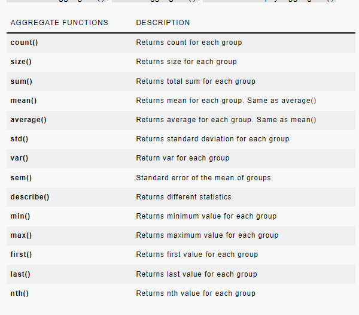

[Spark by Examples](https://sparkbyexamples.com/pandas/pandas-aggregate-functions-with-examples/)

```python
teams_new.describe() #shows the several descriptive statistics of the numerical variables.
```

|  | ranking | games | wins | draws | losses | goalsFor | goalsAgainst | yellowCards | redCards |
| --- | --- | --- | --- | --- | --- | --- | --- | --- | --- |
| count | 32.000000 | 32.000000 | 32.000000 | 32.000000 | 32.000000 | 32.00000 | 32.000000 | 32.000000 | 32.000000 |
| mean | 26.031250 | 3.875000 | 1.437500 | 1.000000 | 1.437500 | 4.34375 | 4.343750 | 7.156250 | 0.500000 |
| std | 24.233387 | 1.070122 | 1.522678 | 0.879883 | 0.715609 | 3.28839 | 2.208625 | 2.760427 | 0.718421 |
| min | 1.000000 | 3.000000 | 0.000000 | 0.000000 | 0.000000 | 0.00000 | 1.000000 | 2.000000 | 0.000000 |
| 25% | 8.750000 | 3.000000 | 0.750000 | 0.000000 | 1.000000 | 2.00000 | 3.000000 | 5.000000 | 0.000000 |
| 50% | 19.500000 | 3.500000 | 1.000000 | 1.000000 | 1.000000 | 3.00000 | 5.000000 | 7.000000 | 0.000000 |
| 75% | 32.500000 | 4.250000 | 2.000000 | 1.250000 | 2.000000 | 5.25000 | 5.000000 | 8.250000 | 1.000000 |
| max | 105.000000 | 6.000000 | 6.000000 | 3.000000 | 3.000000 | 13.00000 | 12.000000 | 15.000000 | 2.000000 |

```python
teams_new.describe().transpose() #by transposing, you can have a better view
```

|  | count | mean | std | min | 25% | 50% | 75% | max |
| --- | --- | --- | --- | --- | --- | --- | --- | --- |
| ranking | 32.0 | 26.03125 | 24.233387 | 1.0 | 8.75 | 19.5 | 32.50 | 105.0 |
| games | 32.0 | 3.87500 | 1.070122 | 3.0 | 3.00 | 3.5 | 4.25 | 6.0 |
| wins | 32.0 | 1.43750 | 1.522678 | 0.0 | 0.75 | 1.0 | 2.00 | 6.0 |
| draws | 32.0 | 1.00000 | 0.879883 | 0.0 | 0.00 | 1.0 | 1.25 | 3.0 |
| losses | 32.0 | 1.43750 | 0.715609 | 0.0 | 1.00 | 1.0 | 2.00 | 3.0 |
| goalsFor | 32.0 | 4.34375 | 3.288390 | 0.0 | 2.00 | 3.0 | 5.25 | 13.0 |
| goalsAgainst | 32.0 | 4.34375 | 2.208625 | 1.0 | 3.00 | 5.0 | 5.00 | 12.0 |
| yellowCards | 32.0 | 7.15625 | 2.760427 | 2.0 | 5.00 | 7.0 | 8.25 | 15.0 |
| redCards | 32.0 | 0.50000 | 0.718421 | 0.0 | 0.00 | 0.0 | 1.00 | 2.0 |

What is missing in the output above?

Categorical variables, i.e object type variables.

```python
teams_new.describe(include=['O'])
```

|  | team | continent |
| --- | --- | --- |
| count | 32 | 32 |
| unique | 32 | 6 |
| top | Brazil | Europe |
| freq | 1 | 13 |

If you would like to apply your function onto specific column, you can use `.values` or `value` attributes. For example,

```python
teams_new['wins'].values.mean() #the average wins
```

```
1.4375
```

```python
teams_new['continent'].value_counts() #frequency distribution of continent
```

```
Europe           13
South America     7
Africa            6
Asia              3
Australia         2
North America     1
Name: continent, dtype: int64
```

```python
teams_by_continent.aggregate('mean') #calculate the average of each variable by continent.
```

| continent | ranking | games | wins | draws | losses | goalsFor | goalsAgainst | yellowCards | redCards |
| --- | --- | --- | --- | --- | --- | --- | --- | --- | --- |
| Africa | 35.333333 | 3.333333 | 0.666667 | 1.000000 | 1.666667 | 2.833333 | 4.000000 | 5.666667 | 0.666667 |
| Asia | 65.666667 | 3.666667 | 1.000000 | 0.666667 | 2.000000 | 3.666667 | 7.333333 | 5.000000 | 0.000000 |
| Australia | 49.000000 | 3.000000 | 0.500000 | 2.000000 | 0.500000 | 2.500000 | 4.000000 | 6.500000 | 1.000000 |
| Europe | 14.153846 | 3.923077 | 1.769231 | 0.769231 | 1.384615 | 4.846154 | 3.846154 | 7.538462 | 0.384615 |
| North America | 14.000000 | 4.000000 | 1.000000 | 2.000000 | 1.000000 | 5.000000 | 5.000000 | 9.000000 | 0.000000 |
| South America | 18.285714 | 4.571429 | 2.000000 | 1.142857 | 1.428571 | 5.428571 | 4.285714 | 8.571429 | 0.714286 |

```python
teams_by_continent.aggregate('count') #shows the frequency of each column by continent.
```

| continent | team | ranking | games | wins | draws | losses | goalsFor | goalsAgainst | yellowCards | redCards |
| --- | --- | --- | --- | --- | --- | --- | --- | --- | --- | --- |
| Africa | 6 | 6 | 6 | 6 | 6 | 6 | 6 | 6 | 6 | 6 |
| Asia | 3 | 3 | 3 | 3 | 3 | 3 | 3 | 3 | 3 | 3 |
| Australia | 2 | 2 | 2 | 2 | 2 | 2 | 2 | 2 | 2 | 2 |
| Europe | 13 | 13 | 13 | 13 | 13 | 13 | 13 | 13 | 13 | 13 |
| North America | 1 | 1 | 1 | 1 | 1 | 1 | 1 | 1 | 1 | 1 |
| South America | 7 | 7 | 7 | 7 | 7 | 7 | 7 | 7 | 7 | 7 |

You can also specify a different aggregation function for each column by passing a dictionary to the aggregate method, where the keys are the column names and the values are the aggregation functions. For example:

```python
teams_by_continent.aggregate({
    "wins": "mean",
    "goalsFor": "max",
    "goalsAgainst": "min"
})
```

| continent | wins | goalsFor | goalsAgainst |
| --- | --- | --- | --- |
| Africa | 0.666667 | 5 | 2 |
| Asia | 1.000000 | 6 | 2 |
| Australia | 0.500000 | 3 | 2 |
| Europe | 1.769231 | 13 | 1 |
| North America | 1.000000 | 5 | 5 |
| South America | 2.000000 | 10 | 2 |

#### **Example 3**

Please read the Players.csv data, and answer the following questions.

```python
players  = pd.read_csv('Players.csv')
players.head()
```

|  | surname | team | position | minutes | shots | passes | tackles | saves |
| --- | --- | --- | --- | --- | --- | --- | --- | --- |
| 0 | Abdoun | Algeria | midfielder | 16 | 0 | 6 | 0 | 0 |
| 1 | Belhadj | Algeria | defender | 270 | 1 | 146 | 8 | 0 |
| 2 | Boudebouz | Algeria | midfielder | 74 | 3 | 28 | 1 | 0 |
| 3 | Bougherra | Algeria | defender | 270 | 1 | 89 | 11 | 0 |
| 4 | Chaouchi | Algeria | goalkeeper | 90 | 0 | 17 | 0 | 2 |

**a)** Show first 5 observations of the data

**b)** How many players are there in the data?

**c)** What is the distribution of positions of the players? (i.e display the frequency of each position)

**d)** What is the average number of pass of the players in WC 2010?

**e)** What is the average minutes that players play by their positions in WC 2010?

**f)** State the surname of the player who has the longest game time.

**g)** State the surname of the goalkeeper who has the highest save.

### **Missing Data**

Missing data occurs when no information is provided. Pandas provides some tools that makes dealing with missing easier.

In pandas, the missing observations have two representations.

- None: None is a Python singleton object that is often used for missing data in Python code.
- NaN : NaN (an acronym for Not a Number), is a special floating-point value recognized by all systems that use the standard IEEE floating-point representation

We can use following functions for missing analysis. i.e We can detect and replace the missing values with these functions

`df.isnull()`

`df.notnull()`

`df.dropna()`

`df.fillna()`

`df.replace()`

Consider the example,

```python
import pandas as pd
```

```python
missing_data = pd.read_csv('https://metustat112.github.io/stolen_cars.csv',sep = ";")
print(missing_data)
```

```
                 Car   Number
0  Chevrolet Pick-Up  48206.0
1       Ford Pick-Up  47999.0
2        Honda Civic  31673.0
3       Honda Accord  30274.0
4       Toyota Camry  17270.0
5        GMC Pick-Up      NaN
6      Nissan Altima  14108.0
7         Honda CR-V      NaN
```

`isnull` and `notnull` works for the same purpose, but returns reverse outputs. While `isnull` returns `True` for missing values, `notnull` returns `True` for available values.

```python
missing_data.isnull()
```

|  | Car | Number |
| --- | --- | --- |
| 0 | False | False |
| 1 | False | False |
| 2 | False | False |
| 3 | False | False |
| 4 | False | False |
| 5 | False | True |
| 6 | False | False |
| 7 | False | True |

```python
missing_data.notnull()
```

|  | Car | Number |
| --- | --- | --- |
| 0 | True | True |
| 1 | True | True |
| 2 | True | True |
| 3 | True | True |
| 4 | True | True |
| 5 | True | False |
| 6 | True | True |
| 7 | True | False |

Instead of having a matrix including boolean values, we can directly compute the total number of missing values for each column in the data as given below.

```python
missing_data.isnull().sum()
```

```
Car       0
Number    2
dtype: int64
```

As seen above, we have 2 missing values in Number column. Apart from the column names, if we would like to compute the total number of the missing observations across the data,

```python
missing_data.isnull().sum().sum() #total number of missing observations
```

```
2
```

**Dealing with Missing Data**

The missing data problem is one of the hardest problem in data science. There are several approaches, including both simple and complex cases.

Before remedying your missing problem in the data, you should figure out the source of the missing and pattern of the missing. After that, you should decide your strategies.

The simplest but most unpreferable solution in missing data is dropping the missing terms.

You can remove the NA values with `dropna`

```python
missing_data.dropna(axis = 0) #axis = 0 removes the rows with na
#axis = 1 drops the columns with na
```

|  | Car | Number |
| --- | --- | --- |
| 0 | Chevrolet Pick-Up | 48206.0 |
| 1 | Ford Pick-Up | 47999.0 |
| 2 | Honda Civic | 31673.0 |
| 3 | Honda Accord | 30274.0 |
| 4 | Toyota Camry | 17270.0 |
| 6 | Nissan Altima | 14108.0 |

The imputing the missing values is better way, sure. You can fill your missing observations via different way. However, we will talk about the simplest way in the context of the course.

`fillna()` fills the all NA values with same value.

```python
missing_data.fillna(0)
```

|  | Car | Number |
| --- | --- | --- |
| 0 | Chevrolet Pick-Up | 48206.0 |
| 1 | Ford Pick-Up | 47999.0 |
| 2 | Honda Civic | 31673.0 |
| 3 | Honda Accord | 30274.0 |
| 4 | Toyota Camry | 17270.0 |
| 5 | GMC Pick-Up | 0.0 |
| 6 | Nissan Altima | 14108.0 |
| 7 | Honda CR-V | 0.0 |

You can use the function to fill the missing values with descriptive statistics.

```python
mean = missing_data['Number'].mean()
median = missing_data['Number'].median()
mode = missing_data['Number'].mode()
print('Mean:',mean,'Median:',median,'Mode:',mode)
```

```
Mean: 31588.333333333332 Median: 30973.5 Mode: 0    14108.0
1    17270.0
2    30274.0
3    31673.0
4    47999.0
5    48206.0
Name: Number, dtype: float64
```

```python
missing_data['Number'].fillna(mean) #mean imputation
```

```
0    48206.000000
1    47999.000000
2    31673.000000
3    30274.000000
4    17270.000000
5    31588.333333
6    14108.000000
7    31588.333333
Name: Number, dtype: float64
```

```python
missing_data['Number'].fillna(median) #mean imputation
```

```
0    48206.0
1    47999.0
2    31673.0
3    30274.0
4    17270.0
5    30973.5
6    14108.0
7    30973.5
Name: Number, dtype: float64
```

```python
missing_data['Number'].fillna(mode) #mean imputation
```

```
0    48206.0
1    47999.0
2    31673.0
3    30274.0
4    17270.0
5    48206.0
6    14108.0
7        NaN
Name: Number, dtype: float64
```

`replace` replaces the value in the specified unit.

```python
missing_data.replace(to_replace=np.nan,value=0) #replaces the all missing values
```

|  | Car | Number |
| --- | --- | --- |
| 0 | Chevrolet Pick-Up | 48206.0 |
| 1 | Ford Pick-Up | 47999.0 |
| 2 | Honda Civic | 31673.0 |
| 3 | Honda Accord | 30274.0 |
| 4 | Toyota Camry | 17270.0 |
| 5 | GMC Pick-Up | 0.0 |
| 6 | Nissan Altima | 14108.0 |
| 7 | Honda CR-V | 0.0 |

#### **Example 4**

Import the `tao.csv` data.

```python
tao = pd.read_csv('tao.csv')
tao.head()
tao_new = tao.drop(['Unnamed: 0'],axis = 1)
tao_new.head()
```

|  | Year | Latitude | Longitude | Sea.Surface.Temp | Air.Temp | Humidity | UWind | VWind |
| --- | --- | --- | --- | --- | --- | --- | --- | --- |
| 0 | 1997 | 0 | -110 | 27.590000 | 27.15 | 79.599998 | -6.4 | 5.4 |
| 1 | 1997 | 0 | -110 | 27.549999 | 27.02 | 75.800003 | -5.3 | 5.3 |
| 2 | 1997 | 0 | -110 | 27.570000 | 27.00 | 76.500000 | -5.1 | 4.5 |
| 3 | 1997 | 0 | -110 | 27.620001 | 26.93 | 76.199997 | -4.9 | 2.5 |
| 4 | 1997 | 0 | -110 | 27.650000 | 26.84 | 76.400002 | -3.5 | 4.1 |

**a)** Calculate the total number of missing observations in the data.

**b)** Which column has the highest number of missing observations in the data?

**c)** Fill the missing values with the mean of the corresponding columns.

**Suggested Sources**

- http://pandas.pydata.org/pandas-docs/stable/
- [Data Manipulation with Pandas](https://www.youtube.com/watch?v=e60ItwlZTKM)
- [Pandas for Everyone](https://www.oreilly.com/library/view/pandas-for-everyone/9780135261118/)
- [Data Analysis with Pandas](https://www.youtube.com/playlist?list=PLQVvvaa0QuDc-3szzjeP6N6b0aDrrKyL-)

[figure not shown]